# EXPLANATORY DATA VISUALIZATION

After doing some data exploration on the titanic dataset, The intended finding of how variables like passenger class, gender of the passenger, age of the passenger could affect result of survivor.

It is well observed that the passenger class had correlation with the outcome of survivor. Another observation was many males succumbed to the tragedy comapared to females.

Another interesting feature was how passenger's age related with the Pclass they aboard.

# 2.0 Explanatory visualization 1

passengers who survived more according to the class they boarded were FIrst class, followed by Second and third class had few number of survivors

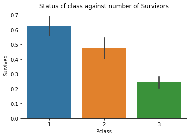

# 2.1 EXPLANATORY VISUALIZATION 2

For each of the passenger class an area is plotted that shows an approximate age for passenger class. Those passengers who were on Third class majority of them were below 30 years.

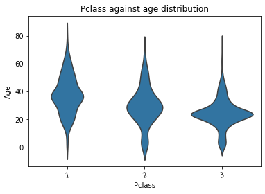

# 2.2 EXPLANATORY VISUALIZATION 3

The number of male who survived was 109 passengers, while the females who survived were 231.

More females survived than males.

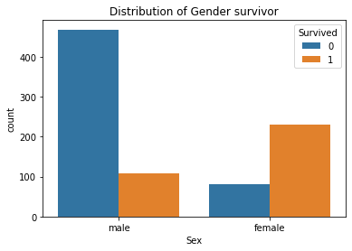

# 2.3 EXPLANATORY VISUALIZATION 4

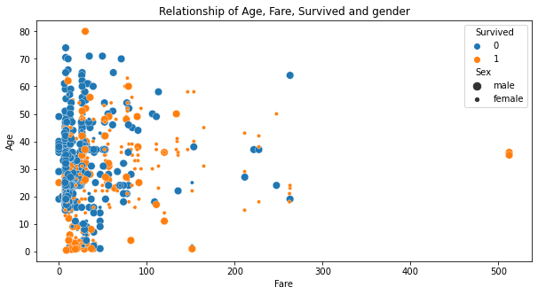